# Exercise 6 Group A

Mia McReynolds, Eli Polzer, Matt Futia

26 February 2021

## Question #1

- Break the predictor variables into logical groups of **topography**, **temperature**, and **precipitation**. Do this by creating a new column called **`pred_type`** and add it the dataframe.

```r
# Load packages
library(tidyverse)
library(data.table)
library(modeest)

# Set working directories
path.root <- "C:/Users/mttft/Desktop/UVM/UVM Courses/SDHM_R/sdhmR-V2021.1EXP"
path.mod2 <- paste(path.root, "/data/module02", sep = "")
path.figs <- paste(path.root, "/powerpoints/figures", sep = "")
path.gis <- paste(path.root, "/data/gis_layers", sep = "")

# Load CRSs
setwd(path.root)
source("r_code/prjs4_sdhmR.r")
ls(pattern = "prj.")
```

```
## [1] "prj.aeaN83"    "prj.gmerc"     "prj.latlong"   "prj.utmWGSz12"
## [5] "prj.wgs84"
```

```r
# Load presence:pseudo-absence and predictor data
load(paste(path.mod2, "/range_pres_psu_data.RData", sep = ""))
```

```r
all_data = range_PPsA_ShortData
pred_groups = data.frame(names(all_data[,18:33]))
names(pred_groups) = "Variable"
topo = c("exp1nrm","exp3nrm","exp5nrm","prad_sw_di","rough_1k","topos")
temp = c("tave_s_hal","tave_sprin","tmax_s_hal","tmax_summe")
precip = c("etpt_5","etpt_6","etpt_sprin","mind_yr_av","prec_w_hal","prec_winte")
pred_groups$pred_type = if_else(pred_groups$Variable %in% topo,"topography",
                                if_else(pred_groups$Variable %in% temp,"temperature", "precipitation"))
```

## Question #2

- Assess correlations:
  - Among all variables; and
  - Within each of the logical groupings created above

```r
cut.point <- 0.7

### Correlations among all variables
c1 <- cor(all_data[, c(18:33)], use = "pairwise.complete.obs", method = "spearman")
c1
```

```
##                 etpt_5      etpt_6  etpt_sprin     exp1nrm     exp3nrm
## etpt_5      1.00000000  0.94071702  0.97798373 -0.06459410 -0.07845235
## etpt_6      0.94071702  1.00000000  0.89455354 -0.05145499 -0.07104813
## etpt_sprin  0.97798373  0.89455354  1.00000000 -0.07101486 -0.07986329
## exp1nrm    -0.06459410 -0.05145499 -0.07101486  1.00000000  0.78111870
## exp3nrm    -0.07845235 -0.07104813 -0.07986329  0.78111870  1.00000000
## exp5nrm    -0.09230445 -0.07950972 -0.08221941  0.36183258  0.65425729
## mind_yr_av -0.96639718 -0.91261083 -0.97159589  0.07273772  0.08459775
## prad_sw_di -0.57623878 -0.39567183 -0.64135317  0.01013561 -0.02995018
## prec_w_hal -0.54683645 -0.55677575 -0.50079201  0.06895189  0.10815043
## prec_winte -0.43855126 -0.47558282 -0.37536077  0.06196939  0.10764853
## rough_1k   -0.43595296 -0.45742529 -0.41430708  0.03716180  0.08154869
## tave_s_hal  0.94252361  0.95459512  0.91075983 -0.06543012 -0.08171025
## tave_sprin  0.97509434  0.93606776  0.97289837 -0.07612876 -0.09449489
## tmax_s_hal  0.93255911  0.93260576  0.91502859 -0.09023215 -0.12232725
## tmax_summe  0.89094525  0.92490792  0.85512871 -0.08651873 -0.12279635
## topos      -0.09283646 -0.09348983 -0.08672106  0.27334431  0.64199574
##                exp5nrm  mind_yr_av   prad_sw_di  prec_w_hal   prec_winte
## etpt_5     -0.09230445 -0.96639718 -0.576238775 -0.54683645 -0.438551260
## etpt_6     -0.07950972 -0.91261083 -0.395671835 -0.55677575 -0.475582824
## etpt_sprin -0.08221941 -0.97159589 -0.641353174 -0.50079201 -0.375360775
## exp1nrm     0.36183258  0.07273772  0.010135605  0.06895189  0.061969394
## exp3nrm     0.65425729  0.08459775 -0.029950182  0.10815043  0.107648525
## exp5nrm     1.00000000  0.08554162  0.031724440  0.10272138  0.108652803
## mind_yr_av  0.08554162  1.00000000  0.565740123  0.57853511  0.450272636
## prad_sw_di  0.03172444  0.56574012  1.000000000  0.15641506  0.006138714
## prec_w_hal  0.10272138  0.57853511  0.156415057  1.00000000  0.964411514
## prec_winte  0.10865280  0.45027264  0.006138714  0.96441151  1.000000000
## rough_1k    0.08338892  0.43273353  0.184088209  0.44902590  0.411810774
## tave_s_hal -0.07655231 -0.93669916 -0.377614712 -0.51980988 -0.433241265
## tave_sprin -0.08466576 -0.96756567 -0.493299064 -0.54583267 -0.444348323
## tmax_s_hal -0.12193365 -0.93725509 -0.396614842 -0.51088474 -0.416133425
## tmax_summe -0.12631106 -0.89314285 -0.295740873 -0.49992907 -0.420893965
## topos       0.74671715  0.09336591 -0.051955516  0.14014859  0.147357056
##               rough_1k  tave_s_hal  tave_sprin  tmax_s_hal  tmax_summe
## etpt_5     -0.43595296  0.94252361  0.97509434  0.93255911  0.89094525
## etpt_6     -0.45742529  0.95459512  0.93606776  0.93260576  0.92490792
## etpt_sprin -0.41430708  0.91075983  0.97289837  0.91502859  0.85512871
## exp1nrm     0.03716180 -0.06543012 -0.07612876 -0.09023215 -0.08651873
## exp3nrm     0.08154869 -0.08171025 -0.09449489 -0.12232725 -0.12279635
```

[output cut: 13 more lines]

```
## etpt_6     -0.09348983
## etpt_sprin -0.08672106
## exp1nrm     0.27334431
## exp3nrm     0.64199574
## exp5nrm     0.74671715
## mind_yr_av  0.09336591
## prad_sw_di -0.05195552
## prec_w_hal  0.14014859
## prec_winte  0.14735706
## rough_1k    0.11575557
## tave_s_hal -0.09602591
## tave_sprin -0.10852208
## tmax_s_hal -0.14899628
## tmax_summe -0.15413481
## topos       1.00000000
```

```r
c2 <- subset(c1 > cut.point | c1 < -cut.point)
c2
```

```
##            etpt_5 etpt_6 etpt_sprin exp1nrm exp3nrm exp5nrm mind_yr_av
## etpt_5       TRUE   TRUE       TRUE   FALSE   FALSE   FALSE       TRUE
## etpt_6       TRUE   TRUE       TRUE   FALSE   FALSE   FALSE       TRUE
## etpt_sprin   TRUE   TRUE       TRUE   FALSE   FALSE   FALSE       TRUE
## exp1nrm     FALSE  FALSE      FALSE    TRUE    TRUE   FALSE      FALSE
## exp3nrm     FALSE  FALSE      FALSE    TRUE    TRUE   FALSE      FALSE
## exp5nrm     FALSE  FALSE      FALSE   FALSE   FALSE    TRUE      FALSE
## mind_yr_av   TRUE   TRUE       TRUE   FALSE   FALSE   FALSE       TRUE
## prad_sw_di  FALSE  FALSE      FALSE   FALSE   FALSE   FALSE      FALSE
## prec_w_hal  FALSE  FALSE      FALSE   FALSE   FALSE   FALSE      FALSE
## prec_winte  FALSE  FALSE      FALSE   FALSE   FALSE   FALSE      FALSE
## rough_1k    FALSE  FALSE      FALSE   FALSE   FALSE   FALSE      FALSE
## tave_s_hal   TRUE   TRUE       TRUE   FALSE   FALSE   FALSE       TRUE
## tave_sprin   TRUE   TRUE       TRUE   FALSE   FALSE   FALSE       TRUE
## tmax_s_hal   TRUE   TRUE       TRUE   FALSE   FALSE   FALSE       TRUE
## tmax_summe   TRUE   TRUE       TRUE   FALSE   FALSE   FALSE       TRUE
## topos       FALSE  FALSE      FALSE   FALSE   FALSE    TRUE      FALSE
##            prad_sw_di prec_w_hal prec_winte rough_1k tave_s_hal tave_sprin
## etpt_5          FALSE      FALSE      FALSE    FALSE       TRUE       TRUE
## etpt_6          FALSE      FALSE      FALSE    FALSE       TRUE       TRUE
## etpt_sprin      FALSE      FALSE      FALSE    FALSE       TRUE       TRUE
## exp1nrm         FALSE      FALSE      FALSE    FALSE      FALSE      FALSE
## exp3nrm         FALSE      FALSE      FALSE    FALSE      FALSE      FALSE
## exp5nrm         FALSE      FALSE      FALSE    FALSE      FALSE      FALSE
## mind_yr_av      FALSE      FALSE      FALSE    FALSE       TRUE       TRUE
## prad_sw_di       TRUE      FALSE      FALSE    FALSE      FALSE      FALSE
## prec_w_hal      FALSE       TRUE       TRUE    FALSE      FALSE      FALSE
## prec_winte      FALSE       TRUE       TRUE    FALSE      FALSE      FALSE
## rough_1k        FALSE      FALSE      FALSE     TRUE      FALSE      FALSE
## tave_s_hal      FALSE      FALSE      FALSE    FALSE       TRUE       TRUE
## tave_sprin      FALSE      FALSE      FALSE    FALSE       TRUE       TRUE
## tmax_s_hal      FALSE      FALSE      FALSE    FALSE       TRUE       TRUE
## tmax_summe      FALSE      FALSE      FALSE    FALSE       TRUE       TRUE
## topos           FALSE      FALSE      FALSE    FALSE      FALSE      FALSE
##            tmax_s_hal tmax_summe topos
## etpt_5           TRUE       TRUE FALSE
## etpt_6           TRUE       TRUE FALSE
## etpt_sprin       TRUE       TRUE FALSE
## exp1nrm         FALSE      FALSE FALSE
## exp3nrm         FALSE      FALSE FALSE
## exp5nrm         FALSE      FALSE  TRUE
## mind_yr_av       TRUE       TRUE FALSE
## prad_sw_di      FALSE      FALSE FALSE
## prec_w_hal      FALSE      FALSE FALSE
## prec_winte      FALSE      FALSE FALSE
## rough_1k        FALSE      FALSE FALSE
## tave_s_hal       TRUE       TRUE FALSE
## tave_sprin       TRUE       TRUE FALSE
## tmax_s_hal       TRUE       TRUE FALSE
## tmax_summe       TRUE       TRUE FALSE
## topos           FALSE      FALSE  TRUE
```

```r
### Correlations within groupings
# Topo correlations
c3 <- cor(dplyr::select(all_data, one_of(topo)), use = "pairwise.complete.obs", method = "spearman")
c_topo <- subset(c3 > cut.point | c3 < -cut.point)
c_topo
```

```
##            exp1nrm exp3nrm exp5nrm prad_sw_di rough_1k topos
## exp1nrm       TRUE    TRUE   FALSE      FALSE    FALSE FALSE
## exp3nrm       TRUE    TRUE   FALSE      FALSE    FALSE FALSE
## exp5nrm      FALSE   FALSE    TRUE      FALSE    FALSE  TRUE
## prad_sw_di   FALSE   FALSE   FALSE       TRUE    FALSE FALSE
## rough_1k     FALSE   FALSE   FALSE      FALSE     TRUE FALSE
## topos        FALSE   FALSE    TRUE      FALSE    FALSE  TRUE
```

```r
# Temp correlations
c4 <- cor(dplyr::select(all_data, one_of(temp)), use = "pairwise.complete.obs", method = "spearman")
c_temp <- subset(c4 > cut.point | c4 < -cut.point)
c_temp
```

```
##            tave_s_hal tave_sprin tmax_s_hal tmax_summe
## tave_s_hal       TRUE       TRUE       TRUE       TRUE
## tave_sprin       TRUE       TRUE       TRUE       TRUE
## tmax_s_hal       TRUE       TRUE       TRUE       TRUE
## tmax_summe       TRUE       TRUE       TRUE       TRUE
```

```r
# Precip correlations
c5 <- cor(dplyr::select(all_data, one_of(precip)), use = "pairwise.complete.obs", method = "spearman")
c_precip <- subset(c5 > cut.point | c5 < -cut.point)
c_precip
```

```
##            etpt_5 etpt_6 etpt_sprin mind_yr_av prec_w_hal prec_winte
## etpt_5       TRUE   TRUE       TRUE       TRUE      FALSE      FALSE
## etpt_6       TRUE   TRUE       TRUE       TRUE      FALSE      FALSE
## etpt_sprin   TRUE   TRUE       TRUE       TRUE      FALSE      FALSE
## mind_yr_av   TRUE   TRUE       TRUE       TRUE      FALSE      FALSE
## prec_w_hal  FALSE  FALSE      FALSE      FALSE       TRUE       TRUE
## prec_winte  FALSE  FALSE      FALSE      FALSE       TRUE       TRUE
```

## Question #3

- Examine variable importance of each predictor variable as related to presence:absence using the process described in the Module.

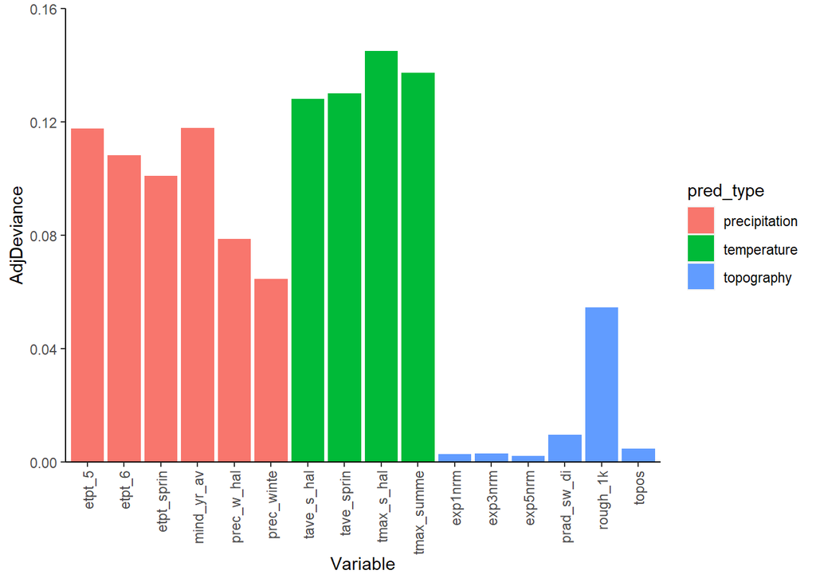

```
From the precipitation variables, etpt_5 and mind_yr_av have similarly high adjusted deviance. Based on temperature, tmax_s_hal has the highest adjusted deviance. Lastly, based on topography, rough_1k has the highest adjusted deviance.
```

```r
### Determine VIP with GLMs
varimp.glm <- function(tr.spp, tr.var, pres, pf, pl) {
  tmp.mat <- matrix(ncol = 2, nrow = (pl - pf + 1))
  for (i in pf:pl) {
    tmp <- glm(tr.spp[, pres] ~ tr.var[, i] + I((tr.var[, i])^2), na.action = na.omit,
      family = binomial)
    tmp.mat[(i - pf + 1), 1] <- tmp$aic
    tmp.mat[(i - pf + 1), 2] <- (1 - (tmp$deviance/tmp$null.deviance))
    }
  return(tmp.mat)
}

tr.vip <- all_data[, c(2, 18:33)]
pres <- 1
v.start <- 2
v.stop <- ncol(tr.vip)
v.num <- v.stop - 1
dev.fit <- varimp.glm(tr.vip, tr.vip, pres, v.start, v.stop)
dev.fit <- data.frame(pred_groups, dev.fit)
setnames(dev.fit, c("X1", "X2"), c("AIC", "AdjDeviance"))

dev.fit1 <- dev.fit[order(dev.fit$pred_type),]
dev.fit$Variable <- factor(dev.fit$Variable,
                           levels = dev.fit$Variable[order(dev.fit$pred_type)])

# Plot AdjDeviance by group
ggplot()+
  geom_col(data = dev.fit, aes(Variable, AdjDeviance, fill = pred_type))+
  scale_y_continuous(limits = c(0,0.16), expand = c(0,0))+
  theme(axis.text.x = element_text(angle = 90, vjust = 0.5, hjust=1),
        panel.background = element_blank(),
        axis.line.x = element_line(color = "black"),
        axis.line.y = element_line(color = "black"))
```

## Question #4

- Eliminate redundant variables with a goal of retaining 7-10 of the 16 available
- Justify your decision(s) to keep / remove variables using bullets

```r
remove = c("etpt_6", "etpt_sprin", "prec_winte", "tave_s_hal", "tave_sprin", "tmax_summe", "exp1nrm", "exp3nrm", "exp5nrm")
tr_RANG = dplyr::select(all_data, !one_of(remove))
```

[output not shown]

## Question #5

- Include the term **tr_MORT**, **tr_PERS**, **tr_RANG**, and **tr_SEED** somewhere in the final training data objects, depending on your data group. Use of **tr_ByGroup** here means the data are now ready for model creation.
- Save your data as R objects:
  - Dataframe;
  - Point shapefile with geometry in R
  - Export as a point shapefile in ESRI format
- Save these R objects in a **`.RData`** file

These data will be used as we next begin the SDHM model constructions.

```r
# Convert data.frame to shapefile
tr_RANG_SF <- st_as_sf(tr_RANG, coords = c("tr.wgs_x", "tr.wgs_y"), crs = prj.wgs84, remove = F)
```

[output not shown]

```r
setwd(path.mod2)
save(tr_RANG, tr_RANG_SF, file = "tr_RANG.Rdata")
```

[output not shown]

```r
st_write(tr_RANG, dsn = ".", layer = "tr_RANG_SF", driver = "ESRI Shapefile", delete_layer = T, delete_dsn = T)
```

[output not shown]